# **Practical Machine Learning Project**

Data used in this project consist of a large amount of data from accelerometers measures on the belt, forearm, arm and dumbell of six participants doing a personal activity in five different ways.

Source data is placed in http://groupware.les.inf.puc-rio.br/har.

The goal of this project is to predict the way in which the exercise is done (predict the activity type) using data from the accelerometers measures.

## **Exploratory analysis**

Those are the dimensions of the training and the validation data sets:

```r
dim(training0)
```

```
## [1] 19622   160
```

```r
dim(validation)
```

```
## [1]  20 160
```

Variable “classe” is the activity type, the variable to be predicted. It is a factor variable with five values:

```r
table(training0$classe)
```

```
##
##    A    B    C    D    E
## 5580 3797 3422 3216 3607
```

Taking a look at the training data set:

```r
str(training0, list.len = 29)
```

```
## 'data.frame':    19622 obs. of  160 variables:
##  $ X                       : int  1 2 3 4 5 6 7 8 9 10 ...
##  $ user_name               : Factor w/ 6 levels "adelmo","carlitos",..: 2 2 2 2 2 2 2 2 2 2 ...
##  $ raw_timestamp_part_1    : int  1323084231 1323084231 1323084231 1323084232 1323084232 1323084232 1323084232 1323084232 1323084232 1323084232 ...
##  $ raw_timestamp_part_2    : int  788290 808298 820366 120339 196328 304277 368296 440390 484323 484434 ...
##  $ cvtd_timestamp          : Factor w/ 20 levels "02/12/2011 13:32",..: 9 9 9 9 9 9 9 9 9 9 ...
##  $ new_window              : Factor w/ 2 levels "no","yes": 1 1 1 1 1 1 1 1 1 1 ...
##  $ num_window              : int  11 11 11 12 12 12 12 12 12 12 ...
##  $ roll_belt               : num  1.41 1.41 1.42 1.48 1.48 1.45 1.42 1.42 1.43 1.45 ...
##  $ pitch_belt              : num  8.07 8.07 8.07 8.05 8.07 8.06 8.09 8.13 8.16 8.17 ...
##  $ yaw_belt                : num  -94.4 -94.4 -94.4 -94.4 -94.4 -94.4 -94.4 -94.4 -94.4 -94.4 ...
##  $ total_accel_belt        : int  3 3 3 3 3 3 3 3 3 3 ...
##  $ kurtosis_roll_belt      : Factor w/ 397 levels "","-0.016850",..: 1 1 1 1 1 1 1 1 1 1 ...
##  $ kurtosis_picth_belt     : Factor w/ 317 levels "","-0.021887",..: 1 1 1 1 1 1 1 1 1 1 ...
##  $ kurtosis_yaw_belt       : Factor w/ 2 levels "","#DIV/0!": 1 1 1 1 1 1 1 1 1 1 ...
```

[output cut: 16 more lines]

Can see that there are a lot of variables with missing values. Checking the missing values:

```r
NAcolumns <- sapply(training0, function(x) sum(is.na(x)))
NAcolumns[NAcolumns>0]
```

```
##            max_roll_belt           max_picth_belt            min_roll_belt
##                    19216                    19216                    19216
##           min_pitch_belt      amplitude_roll_belt     amplitude_pitch_belt
##                    19216                    19216                    19216
##     var_total_accel_belt            avg_roll_belt         stddev_roll_belt
##                    19216                    19216                    19216
##            var_roll_belt           avg_pitch_belt        stddev_pitch_belt
##                    19216                    19216                    19216
##           var_pitch_belt             avg_yaw_belt          stddev_yaw_belt
##                    19216                    19216                    19216
##             var_yaw_belt            var_accel_arm             avg_roll_arm
##                    19216                    19216                    19216
##          stddev_roll_arm             var_roll_arm            avg_pitch_arm
##                    19216                    19216                    19216
##         stddev_pitch_arm            var_pitch_arm              avg_yaw_arm
##                    19216                    19216                    19216
##           stddev_yaw_arm              var_yaw_arm             max_roll_arm
##                    19216                    19216                    19216
##            max_picth_arm              max_yaw_arm             min_roll_arm
##                    19216                    19216                    19216
##            min_pitch_arm              min_yaw_arm       amplitude_roll_arm
##                    19216                    19216                    19216
##      amplitude_pitch_arm        amplitude_yaw_arm        max_roll_dumbbell
##                    19216                    19216                    19216
##       max_picth_dumbbell        min_roll_dumbbell       min_pitch_dumbbell
##                    19216                    19216                    19216
##  amplitude_roll_dumbbell amplitude_pitch_dumbbell       var_accel_dumbbell
##                    19216                    19216                    19216
##        avg_roll_dumbbell     stddev_roll_dumbbell        var_roll_dumbbell
##                    19216                    19216                    19216
##       avg_pitch_dumbbell    stddev_pitch_dumbbell       var_pitch_dumbbell
##                    19216                    19216                    19216
##         avg_yaw_dumbbell      stddev_yaw_dumbbell         var_yaw_dumbbell
##                    19216                    19216                    19216
##         max_roll_forearm        max_picth_forearm         min_roll_forearm
##                    19216                    19216                    19216
##        min_pitch_forearm   amplitude_roll_forearm  amplitude_pitch_forearm
##                    19216                    19216                    19216
##        var_accel_forearm         avg_roll_forearm      stddev_roll_forearm
##                    19216                    19216                    19216
##         var_roll_forearm        avg_pitch_forearm     stddev_pitch_forearm
##                    19216                    19216                    19216
##        var_pitch_forearm          avg_yaw_forearm       stddev_yaw_forearm
##                    19216                    19216                    19216
##          var_yaw_forearm
##                    19216
```

```r
totalNAcolumns <- sum(NAcolumns>0)
NAindex <- which(unlist(sapply(training0, function(x) sum(is.na(x))))>0)
```

There are 67 variables with missing values. They have a high number of rows with missing values so they will be removed from the data sets rather than being imputed with mean or median. Can see that they are all summary statistics variables like max, min or avg.

As it is indicated in the source web page, all the participants have similar caracteristics of sex, age and activity experience. So, participants variable (“user name”) will be removed from the model since there is no variability related to it.

Assuming that timestamp variables are irrelevant to predict the activity type, they will be removed too.

Window variable “num_window” is directly related to the “classe” variable in the way that each window number corresponds to a “classe” value. See some examples:

```r
table(training0$num_window, training0$classe)[c(1,11,19,70,89),]
```

```
##
##       A  B  C  D  E
##   1   0  0  0  0 20
##   11  3  0  0  0  0
##   19  0  0  0 21  0
##   70  0 22  0  0  0
##   89  0  0 15  0  0
```

All rows of the validation data set have “num_window” numbers that are in the training set:

```r
validation$num_window %in% training0$num_window
```

```
##  [1] TRUE TRUE TRUE TRUE TRUE TRUE TRUE TRUE TRUE TRUE TRUE TRUE TRUE TRUE
## [15] TRUE TRUE TRUE TRUE TRUE TRUE
```

So, the truth values of variable “classe” for the validation data set could be known directly mapping the “num_window” variable with the “classe” variable in the training data set.

Since the goal is to build a prediction model to predict the activity type using the accelerometers measures and assuming that window has no relation with those mesures, “num_window” will be removed. Variable “new_window”, directly related with “num_window”, will be removed too.

Checking the near zero variables:

```r
nsv <- nearZeroVar(training0)
totalnsv <- length(nsv)
```

There are 60 near zero variables in the training set that will be removed.

As the result of the previous data cleaning, only variables related to raw data as roll, pitch or yaw, will be used to make the prediction model. Those are the data sets dimensions after the data cleaning process:

```r
training0 <- training0[,-c(1:7, NAindex, nsv)]
validation <- validation[,-c(1:7, NAindex, nsv)]
```

```r
dim(training0)
```

```
## [1] 19622    53
```

```r
dim(validation)
```

```
## [1] 20 53
```

Plotting the data distribution of variables with different measure types (roll, pitch and yaw) on the same site (belt) can see that data is highly skewed:

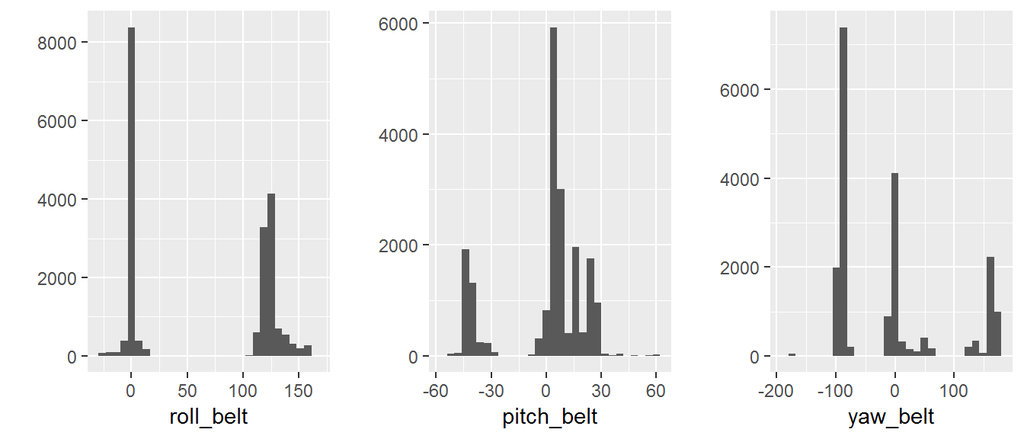

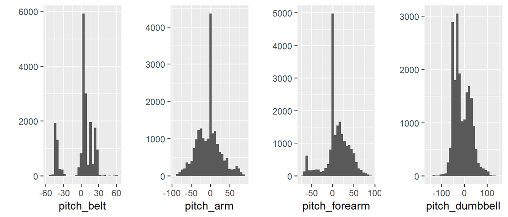

## **Prediction model**

### Building the prediction model

Training data set will be split in two sub sets. A sub training data set (from now on it will be the training set) used to build the model and a testing data set used to test the model.

```r
inTrain <- createDataPartition(y=training0$classe, p=0.70, list=FALSE)
training <- training0[inTrain,]
testing <- training0[-inTrain,]
dim(training)
```

```
## [1] 13737    53
```

```r
dim(testing)
```

```
## [1] 5885   53
```

The prediction model is build using the following settings:

- Data slicing by cross validation method with 10 folds.
- Using parallel processing to optimize the perfomance when building the model.
- Preprocessing data: transforming data by standarization to avoid the skewed original data
- Using random forest method to construct the model.

```r
fitcontrol=trainControl(method="cv",number=10,allowParallel = TRUE)
model <- train(classe ~.,
               method="rf",
               trControl=fitcontrol,
               preProcess=c("center","scale"),
               data=training)
```

### Predicting on testing data set

Applying the model to the testing data:

```r
predictionstesting <- predict(model, testing)
```

Comparing predicted and truth values on the testing data set:

```r
comparisson <- data.frame(predictionstesting,testing$classe)
colnames(comparisson) <- c("Prediction", "Truth")
table(comparisson$Prediction, comparisson$Truth)
```

```
##
##        A    B    C    D    E
##   A 1674    1    0    0    0
##   B    0 1138    4    0    0
##   C    0    0 1022    8    0
##   D    0    0    0  955    0
##   E    0    0    0    1 1082
```

Checking the accuracy of the model:

```r
confusionMatrix(predictionstesting,testing$classe)$overall["Accuracy"]
```

```
##  Accuracy
## 0.9976211
```

Applying the model to the validation data:

```r
predictions <- predict(model, validation)
```

Those are the prediction results on the validation data set: B, A, B, A, A, E, D, B, A, A, B, C, B, A, E, E, A, B, B, B

The out of sample error may be higher (lower accuracy) since prediction on the training data set (testing is a sub set of training data) use to be more optimistic than prediction on the validation data set (out of sample).